# Fitting FX Rates Data to Log-normal Mean Reversion Model

I have come across Mean Reverting process in Quant Finance context from time to time, I am taking this chance to write down some collectives, and learn a bit of writting in **iPython Notebook**.

## The Maths

When it comes to Quantitative model, it always start with a bit of maths, here we go...

### Starting with The Common Mean Reverting Process

The SDE for a mean reverting process looks like: $\mathrm{d}x=\alpha(\theta-x) \mathrm{d}t + \sigma \mathrm{d}W$ where: - $\alpha$ is the mean reversion speed, - $\theta$ is the mean reversion level, - $\sigma$ is the volatility, - $W$ is a Brownian Motion. To solve for $x$ analytically, we assume $z=e^{\alpha t} x$ Apply Ito's lemma $\begin{equation} \begin{split} \mathrm{d}z & =\alpha e^{\alpha t} x \mathrm{d}t + e^{\alpha t} \mathrm{d}x \\ & = \alpha e^{\alpha t} x \mathrm{d}t + \alpha e^{\alpha t}(\theta-x) \mathrm{d}t + e^{\alpha t} \sigma \mathrm{d}W \\ & = \alpha \theta e^{\alpha t} \mathrm{d}t + e^{\alpha t} \sigma \mathrm{d}W \\ \end{split} \end{equation}$ Integrate, get: $z_T = z_0 + \theta (e^{\alpha T}-1) + \int_0^T \sigma e^{\alpha t} \mathrm{d}W_t$ So: $x_T=e^{-\alpha T}x_0 + \theta (1-e^{-\alpha T}) + e^{-\alpha T} \int_0^T \sigma e^{\alpha T} \mathrm{d}W_t$

Intuition: The process is called "mean reverting" because there is a force (the strength of which described as mean reversion speed $\alpha$, generally positive) dragging it back to the "mean" level ($\theta$). Because: $\lim_{T \to 0} e^{-\alpha T} = 1 \mathrm{, and } \lim_{T \to +\infty} e^{-\alpha T}=0$ Looking at the analytical form solution $x_T$, the first term "dial down" to zero as $T$ increases; while the second term "dial up" from $0$ to $\theta$ as $T$ increases. The mean of the process tend to the mean level from initial level $x_0$. The third term represents dispersion, $x_T$ is normally distributed. $\lim_{T \to +\infty} \mathbb{E}[x] = \theta$ and, $\lim_{T \to +\infty} \mathbb{Var}[x] = \frac{\sigma^2}{2\alpha}$ Important fact here is the variance does not increase linear on time.

The well-known Hull-White Interest Rate short rate model is based on the above process, the enhancement was replacing $\theta$ with a time function which allows calibrating to the initial yield curve term structure.

### Log-normal Mean Reverting Process

With what we derived in the previous section, let $x=\ln{y}$, we call $y$ follows a log-normal mean reverting process. $y=e^x$, and it is log-normally distributed.

## Data Fitting

A model is only useful if it could be fitted to data and tested.

### Linear Regression

Obviously the difference between the log-normal mean reverting process and the non-log-normal version is just a matter of taking the $log$ value, which means we just need to work out either of them to make it useful. And just at the first glance we can tell the non-log-normal version is nicer to work with. Ok, enough rubbish.. Writing differentiation in discrete form: $\mathrm{d}x=x_{i+1}-x_i$and$\mathrm{d}t=\Delta t$and$\mathrm{d}W=\epsilon\sim\mathbb{N}(0,\sqrt{\Delta t})$ We get: $\begin{equation} \begin{split} x_{i+1}-x_i & =\alpha (\theta-x_i) \Delta t + \sigma \epsilon \\ x_{i+1} & = \alpha \theta \Delta t + (1-\alpha\Delta t)x_i + \sigma\epsilon \end{split} \end{equation}$ What it says is $x_{i+1}$ is a linear function of $x_i$ plus a white noise term. So if we plot $x_{i+1}$ against $x_i$, we expect the scatters to stay more or less a straight line, kind of giving a first impression we've chosen a good model for the data.

### Python

I used Python code to try fitting the above model to USD-GBP historical rates (2009-Mar-24 to 2014-Mar-24).

```python
import matplotlib.pyplot as plt
import numpy as np
from datetime import datetime
from scipy.stats import norm
import scipy.stats as stats

#import data from CSV

convertfunc = lambda x: datetime.strptime(x, '%d/%m/%Y');
col_headers = ["Date", "USD_GBP", "USD_EUR", "USD_JPY", "USDCHF"];


RawRate = np.genfromtxt('/Users/zipenghuang/Dropbox/data/FXRates.csv', delimiter=',',
                        #dtype='object' ,
                        skip_header=1,
                        usecols = (1,2,3,4),
                        names=col_headers,converters={"Date": convertfunc});

RawDate = np.genfromtxt('/Users/zipenghuang/Dropbox/data/FXRates.csv', delimiter=',',
                        dtype='object',
                        skip_header=1,
                        usecols = 0,
                        names=col_headers,converters={"Date": convertfunc});


#data fitting

IX_DateSort = RawDate.argsort();

Rate = RawRate['USD_GBP'][IX_DateSort];
LogRate = np.log(Rate);

z = LogRate[0:-1];
y = LogRate[1:];

P = np.polyfit(z,y,1);

alpha = (1.0-P[0])/(1.0/365);
theta = P[1]/alpha/(1.0/365);

plt.figure();
plt.scatter(z,y);

xx = np.linspace(min(z)*(1-np.sign(min(z))*0.05), max(z)*(1+np.sign(max(z))*0.05), 100);
yy = np.dot(P, np.array([xx**1, xx**0]));
plt.plot(xx,yy,color='r');
plt.xlabel('LogRate[i]');
plt.ylabel('LogRate[i+1]');
plt.title('USD-GBP: LogRate[i+1] vs LogRate[i] compared with fitted line');
plt.show();



Z = np.array([z**1, z**0]);
Residuals = y - np.dot(P, Z);


#calculate mean and std of the residuals
mu, std = norm.fit(Residuals);

plt.figure();
# Plot the histogram.
plt.hist(Residuals, bins=100, normed=True, alpha=0.6, color='g');
# Plot the PDF.
xmin, xmax = plt.xlim();
x = np.linspace(xmin, xmax, 100);
p = norm.pdf(x, mu, std);
plt.plot(x, p, 'k', linewidth=2);
plt.title("Fit results: mu = %.8f,  std = %.8f" % (mu, std));
plt.show();

plt.figure();
stats.probplot(Residuals, dist="norm", plot=plt);
plt.title("Q-Q Plot");
plt.show();


slope, intercept, r_value, p_value, std_err = stats.linregress(z, y)



#Plot time-series against the mean level calculated from the fit
MeanLevel = np.exp(theta);

plt.figure()
plt.plot(RawDate[IX_DateSort],RawRate['USD_GBP'][IX_DateSort],'b-')
plt.xlabel('Date')
plt.ylabel('USD-GBP')
plt.title('USD-GBP Time Series')
plt.axhline(y=MeanLevel ,linewidth=1, color='r')
plt.show()
```

The fit result is: $f(x) = 0.99196289 x -0.00375743$ The below shows the fit looks pretty good. R-square value is 0.98688219223899865

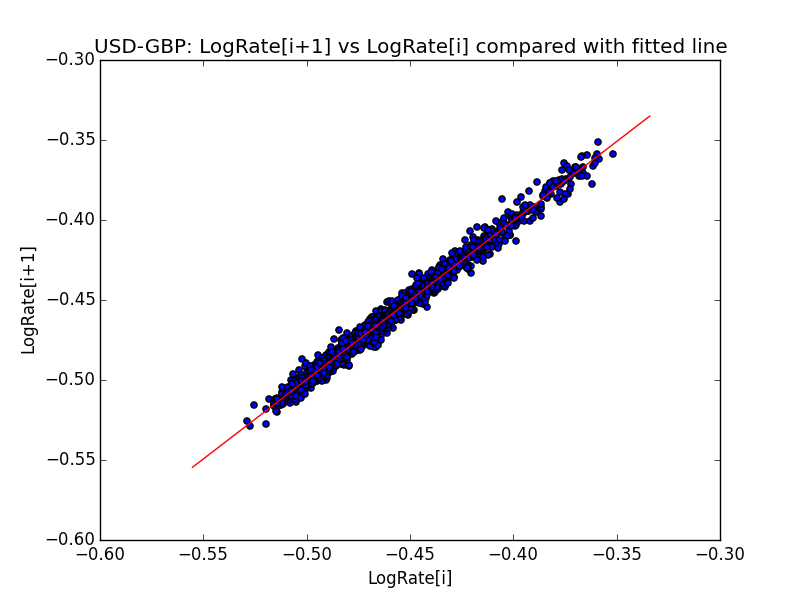

```python
from IPython.display import Image
Image(filename='/Users/zipenghuang/Dropbox/writing/iPythonNotebook/LNMeanReversionModel/scatter.png')
```

The residuals vs. the fitted normal distribution looks like this. Not so pretty..

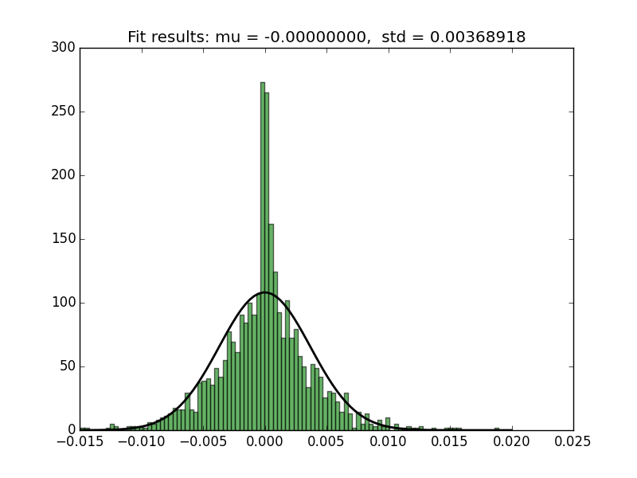

```python
from IPython.display import Image
Image(filename='/Users/zipenghuang/Dropbox/writing/iPythonNotebook/LNMeanReversionModel/Res.png')
```

Does not look very normal, also confirmed by Q-Q plot below:

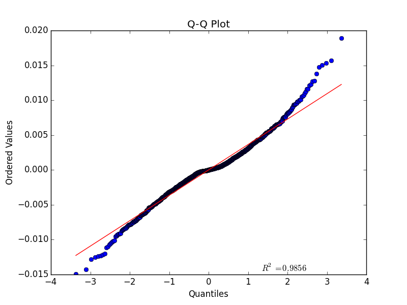

```python
from IPython.display import Image
Image(filename='/Users/zipenghuang/Dropbox/writing/iPythonNotebook/LNMeanReversionModel/QQ.png')
```

The fit suggests a mean reverting level of 0.62656021383357741, below is this level plotted against the time series of the rates.

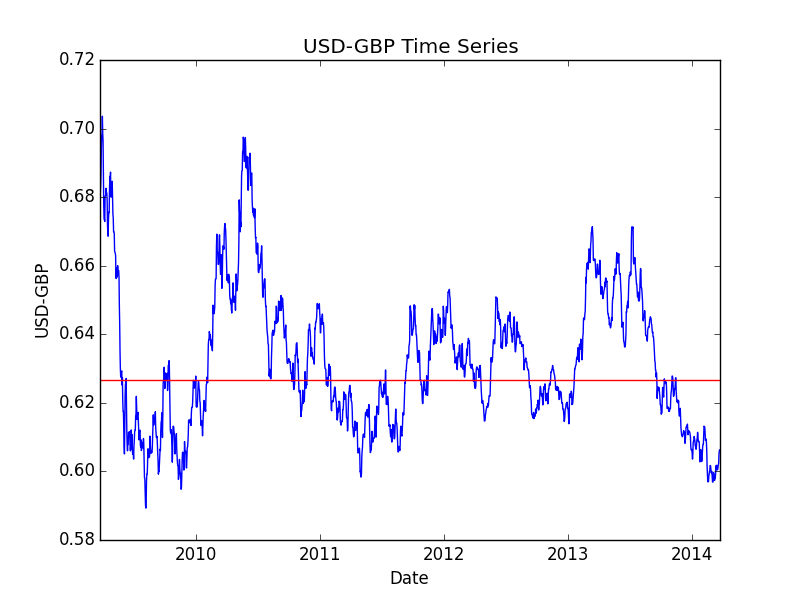

```python
from IPython.display import Image
Image(filename='/Users/zipenghuang/Dropbox/writing/iPythonNotebook/LNMeanReversionModel/TS.png')
```

### Matlab

Below is basically a quick play with Matlab trying to do the same thing done with Python.

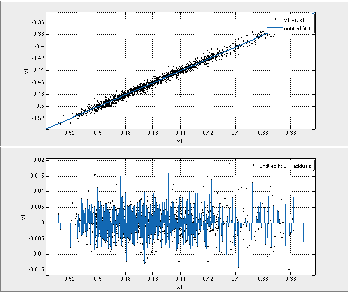

```python
from IPython.display import Image
Image(filename='/Users/zipenghuang/Dropbox/writing/iPythonNotebook/LNMeanReversionModel/FXfit.png')
```

And a quick distribution fit of the residuals to a normal distribution does not seem to suggest the model choice was excellent..

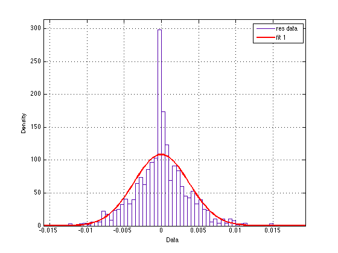

```python
from IPython.display import Image
Image(filename='/Users/zipenghuang/Dropbox/writing/iPythonNotebook/LNMeanReversionModel/ResidualDistributionFit.png')
```

Anyway, Matlab gives the linear fit results as:

Linear model Poly1: f(x) = p1*x + p2 Coefficients (with 95% confidence bounds): p1 = 0.9916 (0.9862, 0.997) p2 = -0.003796 (-0.006311, -0.001281) Goodness of fit: SSE: 0.01834 R-square: 0.9896 Adjusted R-square: 0.9896 RMSE: 0.003675